# Study on Blood Pressure and Level of Hemoglobin

Mehmet Kadri GOFRALILAR - Hasan Ali ÖZKAN

6/6/2022

## 1) About Our Data

Our datasets consist of gathered information of patients in order to discover the factors of adrenal and thyroid disorder and fixing the problem underneath.

First, let’s upload our datasets.

```r
first_data <- read.csv("first_data.csv")
second_data <- read.csv("second_data.csv")
```

## 2) Exploratory and Descriptive Data Analysis

Now, let’s take a look at our datasets and their structures.

```r
str(first_data)
```

```
## 'data.frame':    2000 obs. of  14 variables:
##  $ Patient_Number               : int  1 2 3 4 5 6 7 8 9 10 ...
##  $ Blood_Pressure_Abnormality   : int  1 0 1 0 1 0 1 0 0 1 ...
##  $ Level_of_Hemoglobin          : num  11.28 9.75 10.79 11 14.17 ...
##  $ Age                          : int  34 54 70 71 52 23 43 48 72 40 ...
##  $ BMI                          : int  23 33 49 50 19 48 41 20 44 44 ...
##  $ Sex                          : int  1 1 0 0 0 0 1 0 0 0 ...
##  $ Pregnancy                    : int  1 NA NA NA NA NA 1 NA NA NA ...
##  $ Smoking                      : int  0 0 0 0 0 1 0 0 0 0 ...
##  $ Physical_activity            : int  45961 26106 9995 10635 15619 27042 38369 29781 814 1278 ...
##  $ salt_content_in_the_diet     : int  48071 25333 29465 7439 49644 7513 32967 26749 9607 12715 ...
##  $ alcohol_consumption_per_day  : int  NA 205 67 242 397 NA 206 134 99 95 ...
##  $ Level_of_Stress              : int  2 3 2 1 2 3 3 2 3 2 ...
##  $ Chronic_kidney_disease       : int  1 0 1 1 0 0 1 0 0 0 ...
##  $ Adrenal_and_thyroid_disorders: int  1 0 0 0 0 0 1 0 0 0 ...
```

```r
str(second_data)
```

```
## 'data.frame':    50 obs. of  6 variables:
##  $ Subject      : chr  "D1" "D2" "D3" "D4" ...
##  $ Treatment    : int  1 1 1 1 1 1 1 1 1 1 ...
##  $ Age          : int  65 59 60 54 65 57 69 62 49 45 ...
##  $ Gender       : chr  "F" "F" "M" "F" ...
##  $ Before_exp_BP: num  103.3 93.6 92 93 95.4 ...
##  $ After_exp_BP : num  80.5 85.9 85.2 87.8 85.3 94.2 83.9 85 86.3 90 ...
```

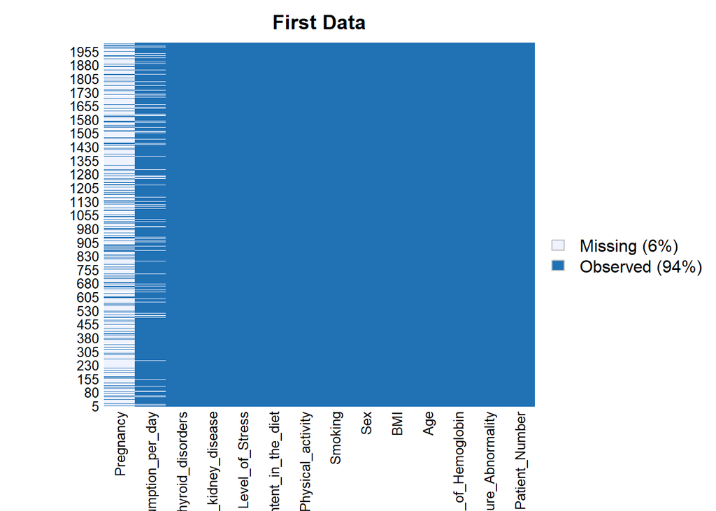

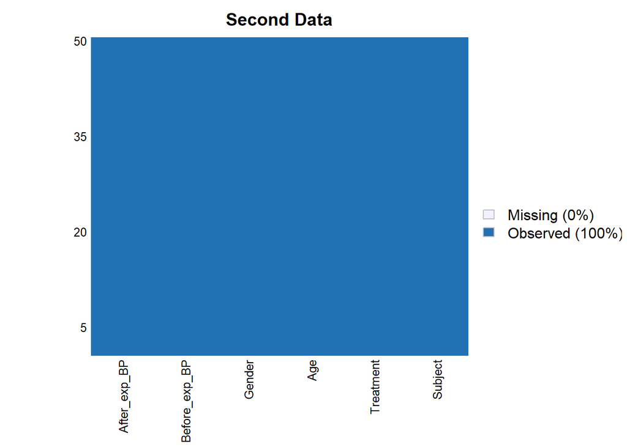

```r
missmap(first_data,main = "First Data")
missmap(second_data,main = "Second Data")
```

We can see that there are missing values in columns *Pregnancy* and *alcohol_consumption_per_day* in the first dataset and there are no missing values in the second dataset. We should impute them if we can.  
We know that *Pregnancy* is a nominal variable, and *alcohol_consumption_per_day* is a cardinal variable. After investigating all variables in detail, we can see that **“0”** means *Male* and **“1”** means *Female* in the column *Sex*. Therefore when the patient is a Male, since there is no chance of pregnancy, a separating value could be assigned such as 2. And when the patient is a Female and the value is missing, we assume that the patient is not pregnant, therefore 0 could be assigned.  
We also assume that the missing values in *alcohol_consumption_per_day* are 0, since they probably don’t drink, therefore there aren’t any entries.  
Let’s impute these missing values.

```r
first_data[which(first_data$Sex=='0'), ]$Pregnancy=2
first_data[which(first_data$Sex=='1'& is.na(first_data$Pregnancy)), ]$Pregnancy=0

first_data[which(is.na(first_data$alcohol_consumption_per_day)), ]$alcohol_consumption_per_day=0
```

Now, let’s factorize the columns that are categorical.

```r
first_data$Blood_Pressure_Abnormality <- as.factor(first_data$Blood_Pressure_Abnormality)
first_data$Sex <- as.factor(first_data$Sex)
first_data$Smoking <- as.factor(first_data$Smoking)
first_data$Level_of_Stress <- as.factor(first_data$Level_of_Stress)
first_data$Chronic_kidney_disease <- as.factor(first_data$Chronic_kidney_disease)
first_data$Adrenal_and_thyroid_disorders <- as.factor(first_data$Adrenal_and_thyroid_disorders)
first_data$Pregnancy <- as.factor(first_data$Pregnancy)


second_data$Gender <- as.factor(second_data$Gender)
second_data$Treatment <- as.factor(second_data$Treatment)
```

Let’s check the structures again.

```r
str(first_data)
```

```
## 'data.frame':    2000 obs. of  14 variables:
##  $ Patient_Number               : int  1 2 3 4 5 6 7 8 9 10 ...
##  $ Blood_Pressure_Abnormality   : Factor w/ 2 levels "0","1": 2 1 2 1 2 1 2 1 1 2 ...
##  $ Level_of_Hemoglobin          : num  11.28 9.75 10.79 11 14.17 ...
##  $ Age                          : int  34 54 70 71 52 23 43 48 72 40 ...
##  $ BMI                          : int  23 33 49 50 19 48 41 20 44 44 ...
##  $ Sex                          : Factor w/ 2 levels "0","1": 2 2 1 1 1 1 2 1 1 1 ...
##  $ Pregnancy                    : Factor w/ 3 levels "0","1","2": 2 1 3 3 3 3 2 3 3 3 ...
##  $ Smoking                      : Factor w/ 2 levels "0","1": 1 1 1 1 1 2 1 1 1 1 ...
##  $ Physical_activity            : int  45961 26106 9995 10635 15619 27042 38369 29781 814 1278 ...
##  $ salt_content_in_the_diet     : int  48071 25333 29465 7439 49644 7513 32967 26749 9607 12715 ...
##  $ alcohol_consumption_per_day  : num  0 205 67 242 397 0 206 134 99 95 ...
##  $ Level_of_Stress              : Factor w/ 3 levels "1","2","3": 2 3 2 1 2 3 3 2 3 2 ...
##  $ Chronic_kidney_disease       : Factor w/ 2 levels "0","1": 2 1 2 2 1 1 2 1 1 1 ...
##  $ Adrenal_and_thyroid_disorders: Factor w/ 2 levels "0","1": 2 1 1 1 1 1 2 1 1 1 ...
```

```r
str(second_data)
```

```
## 'data.frame':    50 obs. of  6 variables:
##  $ Subject      : chr  "D1" "D2" "D3" "D4" ...
##  $ Treatment    : Factor w/ 2 levels "0","1": 2 2 2 2 2 2 2 2 2 2 ...
##  $ Age          : int  65 59 60 54 65 57 69 62 49 45 ...
##  $ Gender       : Factor w/ 2 levels "F","M": 1 1 2 1 1 2 2 2 1 1 ...
##  $ Before_exp_BP: num  103.3 93.6 92 93 95.4 ...
##  $ After_exp_BP : num  80.5 85.9 85.2 87.8 85.3 94.2 83.9 85 86.3 90 ...
```

Everything seems to be okay. Now, we should check the linear correlation to see if there is any linear relationship between variables. This might be useful when we are trying to predict the *Level_of_Hemoglobin*.

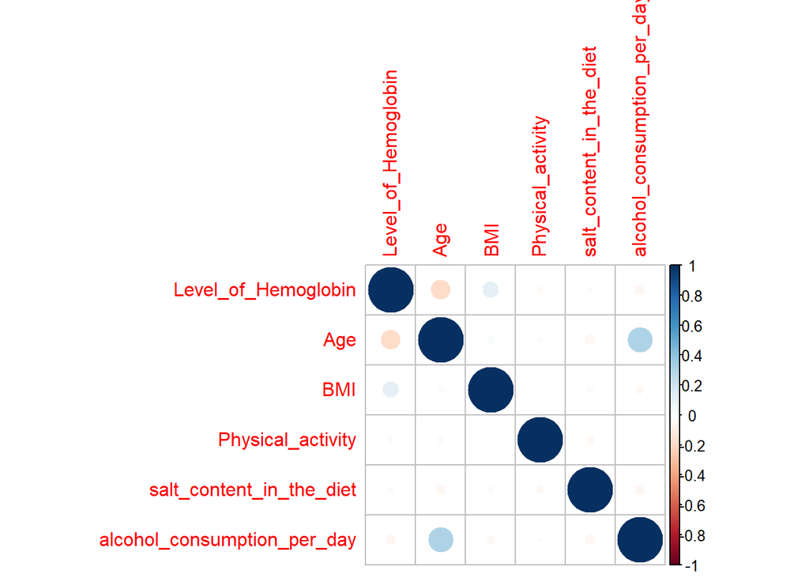

```r
first_data.cor <- cor(first_data[,c(3,4,5,9,10,11)])
corrplot(first_data.cor, method="circle")
```

## 3) Data Visualization

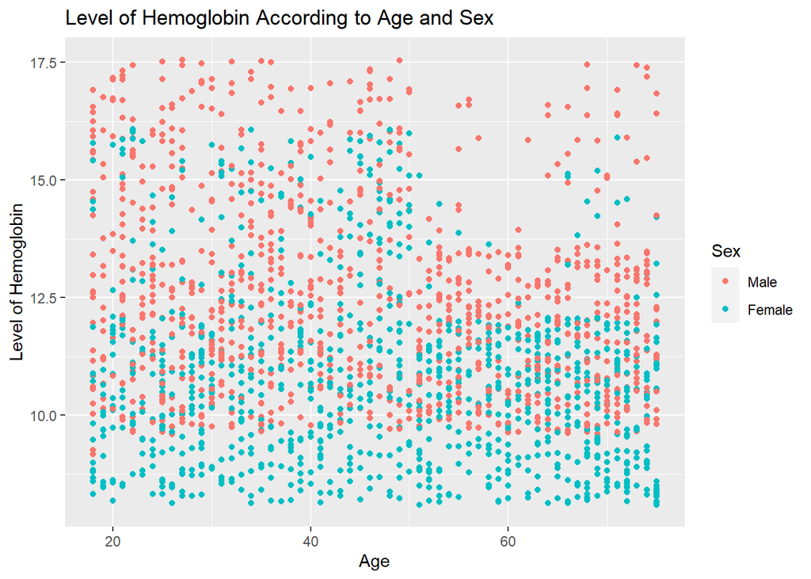

```r
ggplot(first_data, aes(x = Age, y = Level_of_Hemoglobin, color=Sex)) +
  geom_point(stat="identity")+
  scale_color_discrete(labels=c('Male', 'Female'))+
  labs(
    x = "Age",
    y = "Level of Hemoglobin",
    title = "Level of Hemoglobin According to Age and Sex")
```

We can say that Male patients have a higher Hemoglobin level and younger patients also have a higher Hemoglobin level in our sample.  
Now, it would be good if we check the distribution of the *Level_of_Hemoglobin* variable.

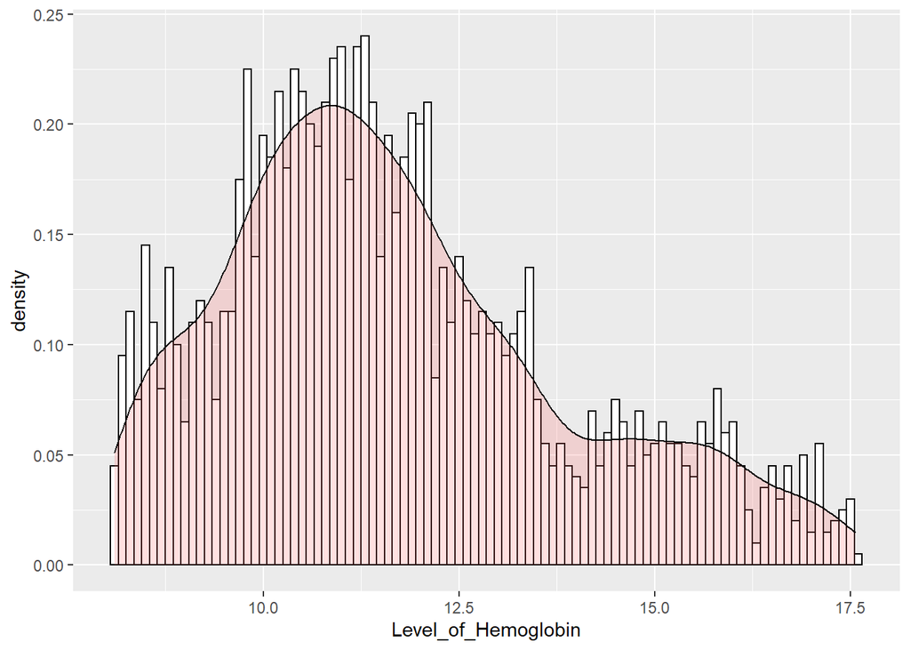

```r
ggplot(first_data, aes(x=Level_of_Hemoglobin)) +
  geom_histogram(aes(y=..density..),colour="black", fill="white",binwidth = 0.1)+
  geom_density(alpha=.2, fill="#FF6666")
```

We can say that the distribution is almost normal but there is a right-skewness. We can fix that by using transformation(such as log-transformation).

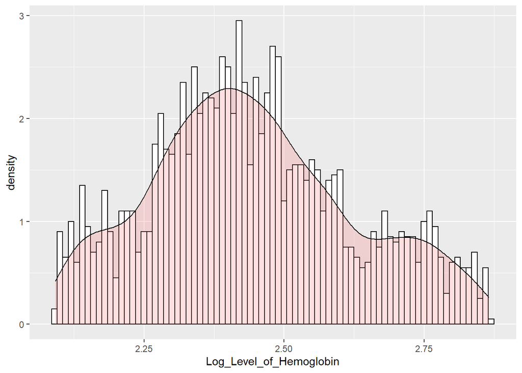

```r
first_data$Log_Level_of_Hemoglobin <- log(first_data$Level_of_Hemoglobin)
ggplot(first_data, aes(x=Log_Level_of_Hemoglobin)) +
  geom_histogram(aes(y=..density..),colour="black", fill="white",binwidth = 0.01)+
  geom_density(alpha=.2, fill="#FF6666")
```

As you can see, it looks much more like a normally distributed variable.  
Now, let’s check whether pregnancy effects the *Level_of_Hemoglobin* or not.

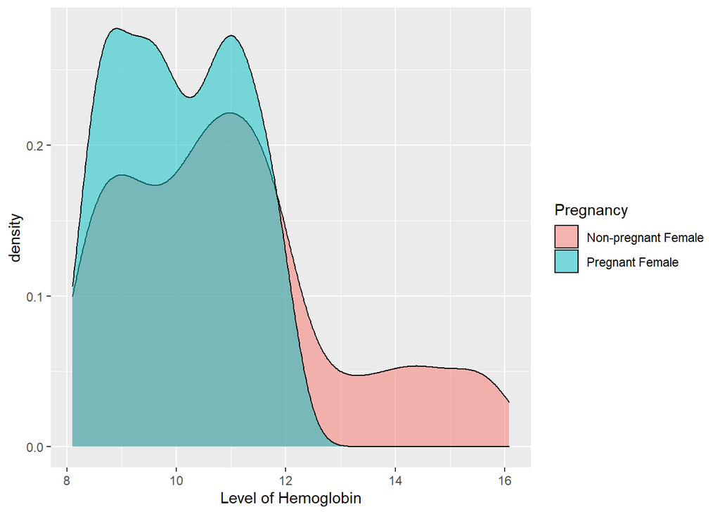

```r
preg_temp <- first_data[which(first_data$Sex=='1'),]
ggplot(preg_temp, aes(x = Level_of_Hemoglobin)) +
  xlab("Level of Hemoglobin") +
  geom_density(aes(fill = Pregnancy), alpha = 0.5)+
  scale_fill_discrete(labels=c('Non-pregnant Female', 'Pregnant Female'))
```

It’s clear that non-pregnant women have higher hemoglobin level.  
Now, we should check the distribution of the blood pressure values of our patients in the second dataset before and after experiment.

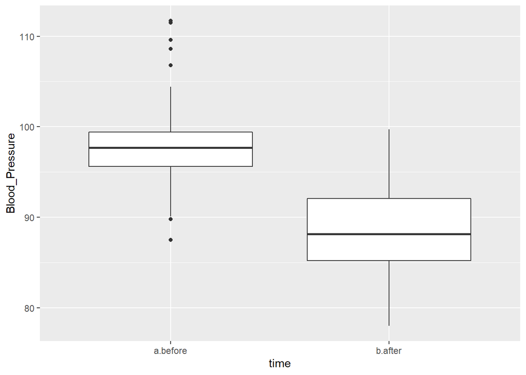

```r
before_exp <- data.frame(as.numeric(second_data$Before_exp_BP))
colnames(before_exp) <- "Blood_Pressure"
before_exp$time <- "a.before"
after_exp <- data.frame(as.numeric(second_data$After_exp_BP))
colnames(after_exp) <- "Blood_Pressure"
after_exp$time <- "b.after"

before_after_table <- rbind(before_exp,after_exp)

ggplot(before_after_table, aes(x=Blood_Pressure, y=time)) +
  geom_boxplot()+ coord_flip()
```

## 4) Central Limit Theorem

Central limit theorem states that when a natural event occurs repeatedly, it is more likely to form a normal distribution in terms of how many times that specific outcome occured compared to other outcomes’.  
In our dataset, we assume that when we take a sample from a patient’s BMI (Body Mass Index) repeatedly and wrote these values down, we would see a normal distribution.  
In order to put this assumption to test, first, from our dataset that has a size of 2000, we took sample with the size of 10 ,and wrote down their mean, repeated this process for 500 times, and then we checked these values’ mean and standard deviation, and then we did the same thing with a sample that has a size of 50. Let’s see the results.

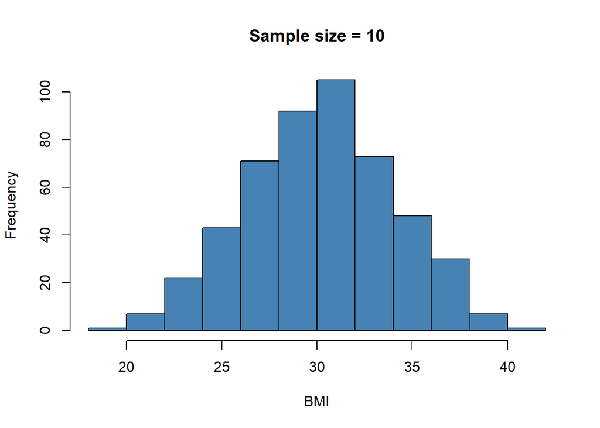

```r
sample10 <- c()

n = 500
for (i in 1:n){
  sample10[i] = mean(sample(first_data$BMI, 10, replace=TRUE))
}

hist(sample10, col ='steelblue', xlab='BMI', main='Sample size = 10')
```

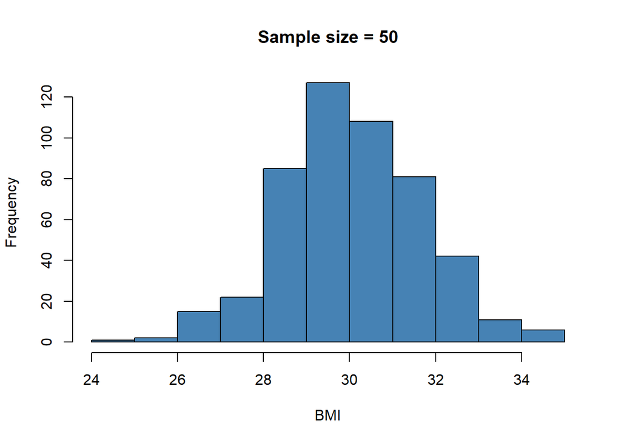

```r
sample50 <- c()
for (i in 1:n){
  sample50[i] = mean(sample(first_data$BMI, 50, replace=TRUE))
}

hist(sample50, col ='steelblue', xlab='BMI', main='Sample size = 50')
```

```r
Mean <- mean(sample10)
Standart_Deviation <- sd(sample10)
sample10df <- t(data.frame(Mean, Standart_Deviation))

sample50.mean <- mean(sample50)
sample50.sd <- sd(sample50)
sample50df <- t(data.frame(sample50.mean,sample50.sd))

mean_sd_df <- cbind(sample10df, sample50df)
colnames(mean_sd_df) <- c("Sample (n=10)","Sample (n=50)")

kable(t(mean_sd_df), format = "markdown")
```

|  | Mean | Standart_Deviation |
| --- | --- | --- |
| Sample (n=10) | 30.22580 | 3.871037 |
| Sample (n=50) | 30.08904 | 1.601521 |

While the mean is almost the same, the standard deviation is down to more than it’s half. Which shows that when the sample size increases, the values becomes closer to mean.

## 5) Confidence Interval

```r
level_of_hemoglobin_mean <- mean(first_data$Level_of_Hemoglobin)
level_of_hemoglobin_sd <- sd(first_data$Level_of_Hemoglobin)
level_of_hemoglobin_se <- level_of_hemoglobin_sd/sqrt(length(first_data))
t.score <-  qt(p=0.05, df=1999,lower.tail=F)

error <- t.score * level_of_hemoglobin_se
lower.bound <- level_of_hemoglobin_mean  - error
upper.bound <- level_of_hemoglobin_mean  + error

print(paste("CI for hemoglobin-level: ", lower.bound, "-", upper.bound))
```

```
## [1] "CI for hemoglobin-level:  10.7809140155965 - 12.6391559844035"
```

```r
BMI_mean <- mean(first_data$BMI)
BMI_sd <- sd(first_data$BMI)
BMI_se <- BMI_sd/sqrt(length(first_data))
t.score <-  qt(p=0.05, df=1999,lower.tail=F)

error <- t.score * BMI_se
lower.bound <- BMI_mean  - error
upper.bound <- BMI_mean  + error

print(paste("CI for BMI: ", lower.bound, "-", upper.bound))
```

```
## [1] "CI for BMI:  25.0842062466841 - 35.0787937533159"
```

## 6) Transformation

We performed log-transformation in the data visualization section before as follows:

```r
# first_data$Log_Level_of_Hemoglobin <- log(first_data$Level_of_Hemoglobin)
```

It was obvious that the variable was looking much more like a normally distributed variable than before.

## 7) Single t-test

### a. Aim

We wanted to compare the *Level_of_Hemoglobin* of the smoking patients and not smoking patients. In detail, our hypothesis is :  
The means of *Level_of_Hemoglobin*s of the patients who smoke and who doesn’t smoke are not equal.

### b. Hypothesis and Level of Significance

H0: μ(smoking) = μ(notSmoking) H1: μ(smoking) ≠ μ(notSmoking)  
Our level of significance (α) will be 0.05.

### c. Assumption Check

#### Assumptions of Two Sample t-Test

1. The two samples are random and independent.
2. The populations from which the samples are drawn are either normal or the sample sizes are large.
3. The populations have the same standard deviation.

Since our samples are random and independent, also their sizes are large, assumptions 1 and 2 are valid. Now, we will check if the assumption 3 is valid.

```r
not_Smoking <- data.frame(first_data[which(first_data$Smoking=='0'), ]$Level_of_Hemoglobin)
colnames(not_Smoking) <- "Level_of_Hemoglobin of Not Smoking Patients"
smoking <- data.frame(first_data[which(first_data$Smoking=='1'), ]$Level_of_Hemoglobin)
colnames(smoking) <- "Level_of_Hemoglobin of Smoking Patients"

sd(not_Smoking$`Level_of_Hemoglobin of Not Smoking Patients`)
```

```
## [1] 2.125155
```

```r
sd(smoking$`Level_of_Hemoglobin of Smoking Patients`)
```

```
## [1] 2.244261
```

```r
var.test(not_Smoking$`Level_of_Hemoglobin of Not Smoking Patients`, smoking$`Level_of_Hemoglobin of Smoking Patients`)
```

```
##
##  F test to compare two variances
##
## data:  not_Smoking$`Level_of_Hemoglobin of Not Smoking Patients` and smoking$`Level_of_Hemoglobin of Smoking Patients`
## F = 0.89667, num df = 980, denom df = 1018, p-value = 0.08518
## alternative hypothesis: true ratio of variances is not equal to 1
## 95 percent confidence interval:
##  0.7920723 1.0152411
## sample estimates:
## ratio of variances
##          0.8966744
```

### d. Which Test to Use

```r
smokingTransformed <- log(smoking$`Level_of_Hemoglobin of Smoking Patients`)
notSmokingTransformed <- log(not_Smoking$`Level_of_Hemoglobin of Not Smoking Patients`)
shapiro.test(smokingTransformed)
```

```
##
##  Shapiro-Wilk normality test
##
## data:  smokingTransformed
## W = 0.97748, p-value = 1.815e-11
```

```r
shapiro.test(notSmokingTransformed)
```

```
##
##  Shapiro-Wilk normality test
##
## data:  notSmokingTransformed
## W = 0.9831, p-value = 3.085e-09
```

Since our p-values are much smaller than 0.05, we can see that the samples are not normally distributed. But, still, let’s check the density plots.

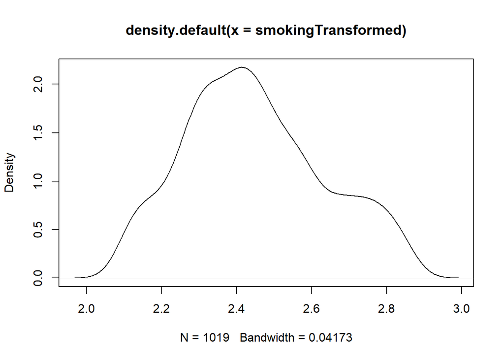

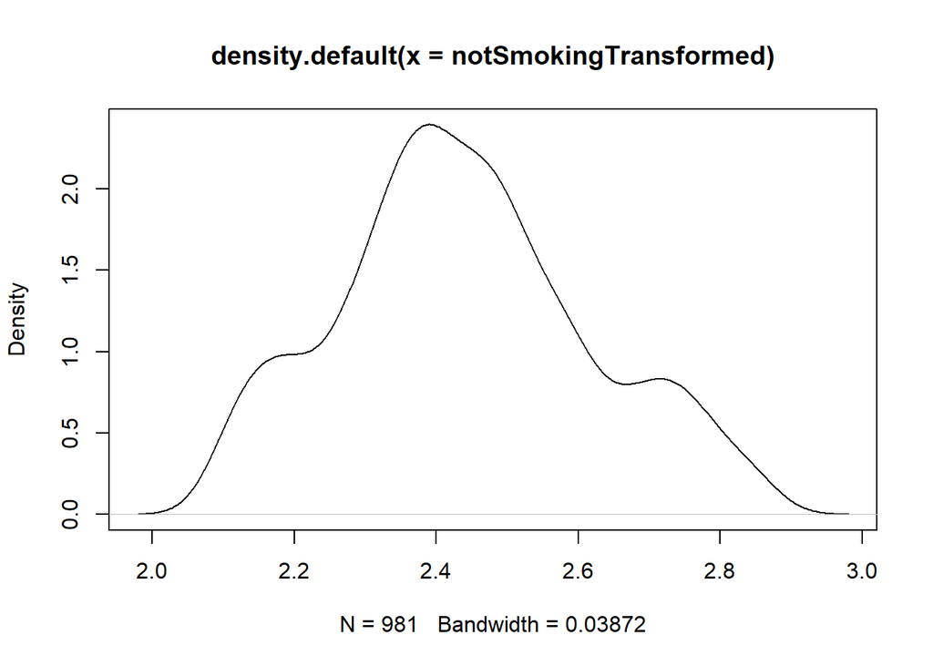

```r
plot(density(smokingTransformed))
plot(density(notSmokingTransformed))
```

We can see that the populations are approximately normally distributed in these density plots, therefore we can use Welch’s t-test.

### e. Result

```r
t.test(smokingTransformed,notSmokingTransformed,conf.level = 0.95)
```

```
##
##  Welch Two Sample t-test
##
## data:  smokingTransformed and notSmokingTransformed
## t = 0.89646, df = 1998, p-value = 0.3701
## alternative hypothesis: true difference in means is not equal to 0
## 95 percent confidence interval:
##  -0.008643303  0.023198362
## sample estimates:
## mean of x mean of y
##  2.447275  2.439997
```

### g. Errors

Type 1 Error: If we incorrectly reject H0, that means we concluded that the means are not equal when they are. Type 2 Error: If we incorrectly fail to reject H0, that means we concluded that the means are equal when they are not.

## 8) Paired t-test

### a. Aim

We wanted to compare the blood pressures of patients before and after the experiment. In detail, our hypothesis is :  
The experiment decreases the blood pressures 10 units on average.

### b. Hypothesis and Level of Significance

H0: μ(before) - μ(after) = 10 H1: μ(before) - μ(after) ≠ 10  
Our level of significance (α) will be 0.05.

### c. Assumption Check

Since we have dependant data, due to values being the results of the same patients under different conditions, we need to use paired t-test.

#### Assumptions of Paired t-Test

1. The sample is random.
2. The data is matched pairs.
3. The differences have a normal distribution or the sample size is large.

First two assumptions are valid. Now, we should check if the assumption 3 is valid or violated.

```r
difference <- second_data$Before_exp_BP - second_data$After_exp_BP
mean(difference)
```

```
## [1] 9.704
```

```r
shapiro.test(difference)
```

```
##
##  Shapiro-Wilk normality test
##
## data:  difference
## W = 0.91583, p-value = 0.001672
```

Since the p-value is much smaller than 0.05, we can say that the differences between before and after values are not distributed normally. Let’s check the density plot as well.

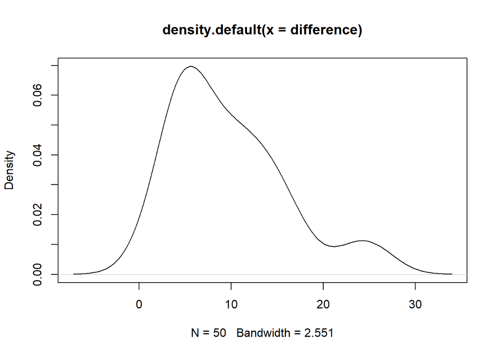

```r
plot(density(difference))
```

As we can see in the density plot as well, differences between values are not distributed normally.

### d. Result

Since the differences between values are not distributed normally, we need to use Wilcoxon Signed Rank Test.

```r
wilcox.test(second_data$After_exp_BP,second_data$Before_exp_BP, paired = TRUE, mu = 10)
```

```
##
##  Wilcoxon signed rank test with continuity correction
##
## data:  second_data$After_exp_BP and second_data$Before_exp_BP
## V = 0, p-value = 7.785e-10
## alternative hypothesis: true location shift is not equal to 10
```

## 9) Fisher’s Exact Test

### a. Aim

We wanted to see if there is an association between smoking and the hemoglobin levels. In detail, our hypothesis is :  
There is an association between smoking and the hemoglobin levels.

### b. Hypothesis and Level of Significance

H0: Smoking doesn’t effect hemoglobin levels. H1: Smoking effect hemoglobin levels.  
Our level of significance (α) will be 0.05.

### c. Result

We should prepare the data to apply Fisher’s Exact Test. In order to do this, we created a new nominal column that shows whether the patient has level of hemoglobin below average or not with values of ones and zeros.

```r
first_data$LOH_below_average <- "Hemoglobin_Level_Below_Average"
for(i in 1:length(first_data$Level_of_Hemoglobin)){
  if(first_data[i,]$Level_of_Hemoglobin<mean(first_data$Level_of_Hemoglobin)){
    first_data[i,]$LOH_below_average = "Hemoglobin_Level_Above_Average"
  }
}

fisher_table <- with(first_data , table(LOH_below_average,Smoking))

fisher_exact_test <- fisher.test(fisher_table, conf.level = 0.95)

kable(fisher_table,
      col.names = c("Not_Smoking","Smoking"))
```

|  | Not_Smoking | Smoking |
| --- | --- | --- |
| Hemoglobin_Level_Above_Average | 560 | 580 |
| Hemoglobin_Level_Below_Average | 421 | 439 |

```r
fisher_exact_test
```

```
##
##  Fisher's Exact Test for Count Data
##
## data:  fisher_table
## p-value = 0.964
## alternative hypothesis: true odds ratio is not equal to 1
## 95 percent confidence interval:
##  0.8400449 1.2066725
## sample estimates:
## odds ratio
##   1.006795
```

Since the p-value is greater than 0.05, we do not reject H0.

### d. Conclusion

The test we did above shows that there is no association between smoking and the level of hemoglobin, which means knowing one value doesn’t mean anything for the other value with 95% confidence.

### e. Odds Ratio

Odds ratio is approximately 1, which indicates that there is no association between these two nominal variables.

## 10) ANOVA and Tukey Test

### a. Aim

We wanted to see if there is an association between alcohol consumption and level of stress. In detail, our hypothesis is :  
Level of stress increases the alcohol consumption.

### b. Hypothesis and Level of Significance

H0: μ(alcohol_consumption_under_low_stress) = μ(alcohol_consumption_under_med_stress) = μ(alcohol_consumption_under_high_stress) H1: μ(alcohol_consumption_under_low_stress) ≠ μ(alcohol_consumption_under_med_stress) ≠ μ(alcohol_consumption_under_high_stress)

### c. Assumption Check

1. Each sample is taken from a normally distributed population
2. Each sample has been drawn independently of the other samples
3. The variance of data in the different groups should be the same
4. The dependent variable should be continuous

Since our samples are independent, the dependant variable is continous, assumptions 2 and 4 are valid. Now, we will check if the assumptions 1 and 3 are valid or violated.

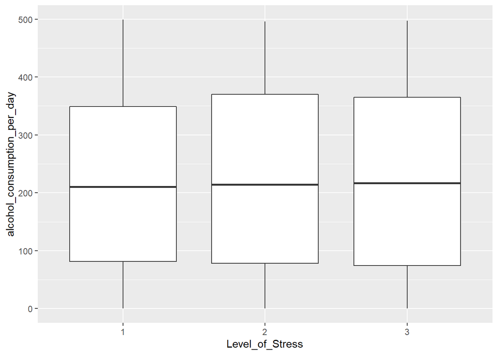

```r
ggplot(first_data, aes(x=alcohol_consumption_per_day, y=Level_of_Stress)) +
  geom_boxplot()+ coord_flip()
```

We can see that the distributions and the variances of these samples are almost identical. Let’s test their normalities.

```r
shapiro.test(first_data[which(first_data$Level_of_Stress==1),]$alcohol_consumption_per_day)
```

```
##
##  Shapiro-Wilk normality test
##
## data:  first_data[which(first_data$Level_of_Stress == 1), ]$alcohol_consumption_per_day
## W = 0.93885, p-value = 6.627e-16
```

```r
shapiro.test(first_data[which(first_data$Level_of_Stress==2),]$alcohol_consumption_per_day)
```

```
##
##  Shapiro-Wilk normality test
##
## data:  first_data[which(first_data$Level_of_Stress == 2), ]$alcohol_consumption_per_day
## W = 0.92956, p-value < 2.2e-16
```

```r
shapiro.test(first_data[which(first_data$Level_of_Stress==3),]$alcohol_consumption_per_day)
```

```
##
##  Shapiro-Wilk normality test
##
## data:  first_data[which(first_data$Level_of_Stress == 3), ]$alcohol_consumption_per_day
## W = 0.92755, p-value < 2.2e-16
```

Seems like there is a problem here, since we reject H0 due to p-value being less than 0.05. Let’s try log-transformation.

```r
shapiro.test(log(first_data[which(first_data$Level_of_Stress==1),]$alcohol_consumption_per_day))
```

```
##
##  Shapiro-Wilk normality test
##
## data:  log(first_data[which(first_data$Level_of_Stress == 1), ]$alcohol_consumption_per_day)
## W = NaN, p-value = NA
```

```r
shapiro.test(log(first_data[which(first_data$Level_of_Stress==2),]$alcohol_consumption_per_day))
```

```
##
##  Shapiro-Wilk normality test
##
## data:  log(first_data[which(first_data$Level_of_Stress == 2), ]$alcohol_consumption_per_day)
## W = NaN, p-value = NA
```

```r
shapiro.test(log(first_data[which(first_data$Level_of_Stress==3),]$alcohol_consumption_per_day))
```

```
##
##  Shapiro-Wilk normality test
##
## data:  log(first_data[which(first_data$Level_of_Stress == 3), ]$alcohol_consumption_per_day)
## W = NaN, p-value = NA
```

```r
first_data_for_anova <- first_data[,c(11,12)]

bartlett.test(alcohol_consumption_per_day~Level_of_Stress,data=first_data_for_anova)
```

```
##
##  Bartlett test of homogeneity of variances
##
## data:  alcohol_consumption_per_day by Level_of_Stress
## Bartlett's K-squared = 1.4665, df = 2, p-value = 0.4803
```

Since the p-value is greater than 0.05, we fail to reject H0, which is: *The variance among each group is equal*. Therefore we can conclude that the variances between these three groups are equal, meaning our third assumption is also valid.

### d. Results of ANOVA

```r
anova_model <- aov(alcohol_consumption_per_day~Level_of_Stress,data=first_data_for_anova)
summary(anova_model)
```

```
##                   Df   Sum Sq Mean Sq F value Pr(>F)
## Level_of_Stress    2    12328    6164   0.248   0.78
## Residuals       1997 49647243   24861
```

### e. Conclusion of ANOVA

The test we did above shows that the level of stress doesn’t effect the alcohol consumption.

### f. Results of Tukey

```r
TukeyHSD(anova_model)
```

```
##   Tukey multiple comparisons of means
##     95% family-wise confidence level
##
## Fit: aov(formula = alcohol_consumption_per_day ~ Level_of_Stress, data = first_data_for_anova)
##
## $Level_of_Stress
##          diff       lwr      upr     p adj
## 2-1  5.936250 -14.50994 26.38244 0.7746232
## 3-1  4.245251 -15.83638 24.32688 0.8733122
## 3-2 -1.690999 -21.95469 18.57270 0.9791024
```

Since each of the adjusted p-values are greater than 0.05, we can conclude that there is no significant difference in the mean values between each group.

### g. Conclusion of Tukey

The test we did above shows that the level of stress doesn’t effect the alcohol consumption.

## 11) Multiple Linear Regression

### a. Aim

We wanted to see if we can predict the *Level_of_Hemoglobin* or not with the values of *Age*, *BMI*, *Physical_activity*, *salt_content_in_the_diet* and *alcohol_consumption_per_day*.

### b. Regression Equation

*Level_of_Hemoglobin* is our response variable.*Age*, *BMI*, *Physical_activity*, *salt_content_in_the_diet* and *alcohol_consumption_per_day* are our explanatory variables.

```r
first_data_for_mlr <- first_data[,c(3,4,5,9,10,11)]
mlr <- lm(Level_of_Hemoglobin~. ,data = first_data_for_mlr)

mlr$coefficients
```

```
##                 (Intercept)                         Age
##                1.215644e+01               -2.439991e-02
##                         BMI           Physical_activity
##                2.293213e-02               -3.176701e-06
##    salt_content_in_the_diet alcohol_consumption_per_day
##                1.561330e-06                1.862652e-04
```

*Level_of_Hemoglobin* = 12.15644 + (-2.439991x10<sup>-2</sup> x *Age*) + (2.293213x10<sup>-2</sup> x *BMI*) + (-3.176701x10<sup>-6</sup> x *Physical_activity*) + (1.561330x10<sup>-6</sup> x *salt_content_in_the_diet*) + (1.862652x10<sup>-4</sup> x *alcohol_consumption_per_day*) + 2.134

### c. Hypothesis and Level of Significance

The null hypothesis states that all coefficients in the model are equal to zero. In other words, none of the predictor variables have a statistically significant relationship with the response variable, y.  
The alternative hypothesis states that not every coefficient is simultaneously equal to zero.  
H0: β1 = β2 = … = βk = 0 H1: β1 = β2 = … = βk ≠ 0  
We will use a level of significance of 95%.

### d. Find the Best Model:

```r
summary(mlr)
```

```
##
## Call:
## lm(formula = Level_of_Hemoglobin ~ ., data = first_data_for_mlr)
##
## Residuals:
##     Min      1Q  Median      3Q     Max
## -4.2673 -1.5346 -0.3137  1.2728  6.3462
##
## Coefficients:
##                               Estimate Std. Error t value Pr(>|t|)
## (Intercept)                  1.216e+01  2.227e-01  54.592  < 2e-16 ***
## Age                         -2.440e-02  2.931e-03  -8.323  < 2e-16 ***
## BMI                          2.293e-02  4.066e-03   5.641 1.94e-08 ***
## Physical_activity           -3.177e-06  3.409e-06  -0.932    0.352
## salt_content_in_the_diet     1.561e-06  3.367e-06   0.464    0.643
## alcohol_consumption_per_day  1.863e-04  3.182e-04   0.585    0.558
## ---
## Signif. codes:  0 '***' 0.001 '**' 0.01 '*' 0.05 '.' 0.1 ' ' 1
##
## Residual standard error: 2.134 on 1994 degrees of freedom
## Multiple R-squared:  0.04986,    Adjusted R-squared:  0.04747
## F-statistic: 20.93 on 5 and 1994 DF,  p-value: < 2.2e-16
```

R has already marked the best explanatory variables in our dataset that all have a smaller p-value than 0.05.

```r
best_model <- step(mlr)
```

```
## Start:  AIC=3038.29
## Level_of_Hemoglobin ~ Age + BMI + Physical_activity + salt_content_in_the_diet +
##     alcohol_consumption_per_day
##
##                               Df Sum of Sq    RSS    AIC
## - salt_content_in_the_diet     1     0.979 9083.0 3036.5
## - alcohol_consumption_per_day  1     1.561 9083.5 3036.6
## - Physical_activity            1     3.954 9085.9 3037.2
## <none>                                     9082.0 3038.3
## - BMI                          1   144.916 9226.9 3067.9
## - Age                          1   315.546 9397.5 3104.6
##
## Step:  AIC=3036.51
## Level_of_Hemoglobin ~ Age + BMI + Physical_activity + alcohol_consumption_per_day
##
##                               Df Sum of Sq    RSS    AIC
## - alcohol_consumption_per_day  1      1.48 9084.4 3034.8
## - Physical_activity            1      4.08 9087.1 3035.4
## <none>                                     9083.0 3036.5
## - BMI                          1    145.63 9228.6 3066.3
## - Age                          1    317.04 9400.0 3103.1
##
## Step:  AIC=3034.83
## Level_of_Hemoglobin ~ Age + BMI + Physical_activity
##
##                     Df Sum of Sq    RSS    AIC
## - Physical_activity  1      4.18 9088.6 3033.8
## <none>                           9084.4 3034.8
## - BMI                1    144.63 9229.1 3064.4
## - Age                1    334.78 9419.2 3105.2
##
## Step:  AIC=3033.75
## Level_of_Hemoglobin ~ Age + BMI
##
##        Df Sum of Sq    RSS    AIC
## <none>              9088.6 3033.8
## - BMI   1    144.91 9233.5 3063.4
## - Age   1    337.07 9425.7 3104.6
```

As we can see above, step() function decreased the number of columns to 2, which are the most important and meaningful columns in order to predict *Level_of_Hemoglobin*.

### e. Assumption Check:

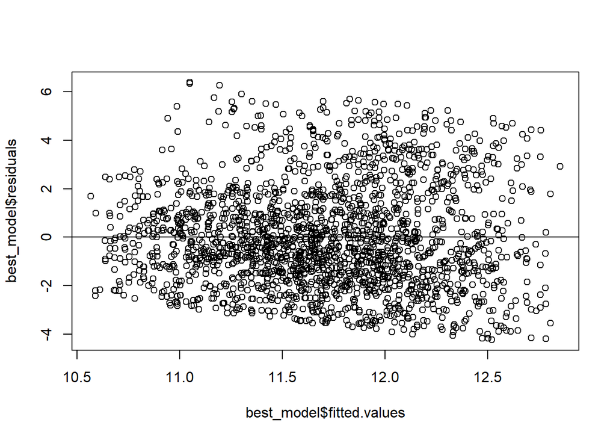

```r
plot(best_model$fitted.values,best_model$residuals, abline(h = 0))
```

Since the points are distributed fairly across all the values of independent variables, we can say that the variance of the residuals is constant.  
4. Independence of observation  
We know that our observations are independent.  
5. Multivariate normality

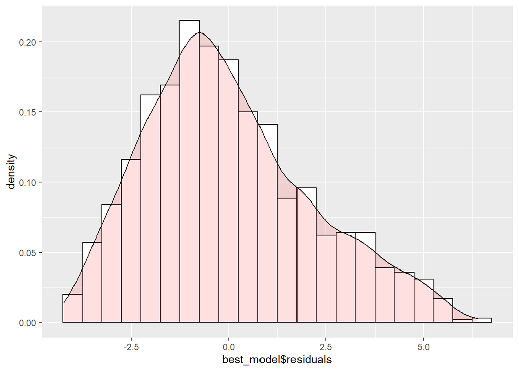

```r
ggplot(best_model, aes(x=best_model$residuals)) +
  geom_histogram(aes(y=..density..),colour="black", fill="white",binwidth = 0.5)+
  geom_density(alpha=.2, fill="#FF6666")
```

### f. Result

```r
summary(mlr)
```

```
##
## Call:
## lm(formula = Level_of_Hemoglobin ~ ., data = first_data_for_mlr)
##
## Residuals:
##     Min      1Q  Median      3Q     Max
## -4.2673 -1.5346 -0.3137  1.2728  6.3462
##
## Coefficients:
##                               Estimate Std. Error t value Pr(>|t|)
## (Intercept)                  1.216e+01  2.227e-01  54.592  < 2e-16 ***
## Age                         -2.440e-02  2.931e-03  -8.323  < 2e-16 ***
## BMI                          2.293e-02  4.066e-03   5.641 1.94e-08 ***
## Physical_activity           -3.177e-06  3.409e-06  -0.932    0.352
## salt_content_in_the_diet     1.561e-06  3.367e-06   0.464    0.643
## alcohol_consumption_per_day  1.863e-04  3.182e-04   0.585    0.558
## ---
## Signif. codes:  0 '***' 0.001 '**' 0.01 '*' 0.05 '.' 0.1 ' ' 1
##
## Residual standard error: 2.134 on 1994 degrees of freedom
## Multiple R-squared:  0.04986,    Adjusted R-squared:  0.04747
## F-statistic: 20.93 on 5 and 1994 DF,  p-value: < 2.2e-16
```

Since p-value of the model is less than 0.05, we can say that our model is meaningful. Also the variables that have a p-value less than 0.05 are meaningful.

```r
summary(best_model)
```

```
##
## Call:
## lm(formula = Level_of_Hemoglobin ~ Age + BMI, data = first_data_for_mlr)
##
## Residuals:
##     Min      1Q  Median      3Q     Max
## -4.2302 -1.5189 -0.3099  1.2598  6.3897
##
## Coefficients:
##              Estimate Std. Error t value Pr(>|t|)
## (Intercept) 12.139088   0.182109  66.658  < 2e-16 ***
## Age         -0.024012   0.002790  -8.606  < 2e-16 ***
## BMI          0.022902   0.004059   5.643 1.91e-08 ***
## ---
## Signif. codes:  0 '***' 0.001 '**' 0.01 '*' 0.05 '.' 0.1 ' ' 1
##
## Residual standard error: 2.133 on 1997 degrees of freedom
## Multiple R-squared:  0.04916,    Adjusted R-squared:  0.04821
## F-statistic: 51.63 on 2 and 1997 DF,  p-value: < 2.2e-16
```

Since p-value of the model is less than 0.05, we can say that our model is meaningful.  
When we look at the Adjusted R-square values, we can see an increase. Therefore it’s safe to say the best_model is a better model than mlr.

### g. Conclusion

We wanted to see if we can predict the *Level_of_Hemoglobin* or not with the values of *Age*, *BMI*, *Physical_activity*, *salt_content_in_the_diet* and *alcohol_consumption_per_day*. But after the processes above, we know that the *Age* and *BMI* columns are enough for us to predict *Level_of_Hemoglobin*.

### h. Prediction

```r
# Prediction for MLR
to_be_predicted_mlr<- data.frame(44,26,27456,30213,400)
colnames(to_be_predicted_mlr) <- c("Age","BMI","Physical_activity","salt_content_in_the_diet","alcohol_consumption_per_day")
predicted_value_mlr <- predict(mlr,newdata = as.data.frame(to_be_predicted_mlr))

# Prediction for Best_Model
to_be_predicted_reduced_mlr <- data.frame(64,36)
colnames(to_be_predicted_reduced_mlr) <- c("Age","BMI")
predicted_value_reduce_mlr <- predict(best_model,newdata = as.data.frame(to_be_predicted_reduced_mlr))

print(paste("Predicted value for MLR: ", predicted_value_mlr))
```

```
## [1] "Predicted value for MLR:  11.7135346978484"
```

```r
print(paste("Predicted value for Best_Model: ", predicted_value_reduce_mlr))
```

```
## [1] "Predicted value for Best_Model:  11.4267704805057"
```